# Part I - Ford GoBike System Data

## Introduction

> This document explores a dataset containing information about individual rides made in a bike-sharing system covering the greater San Francisco Bay area.

## Preliminary Wrangling

```python
# import all packages and set plots to be embedded inline
import numpy as np
import pandas as pd
import matplotlib.pyplot as plt
import seaborn as sb
import geopy.distance

%matplotlib inline
```

> Load in your dataset and describe its properties through the questions below. Try and motivate your exploration goals through this section.

```python
bike_rides = pd.read_csv("201902-fordgobike-tripdata.csv")
```

```python
bike_rides.sample(10)
```

|  | duration_sec | start_time | end_time | start_station_id | start_station_name | start_station_latitude | start_station_longitude | end_station_id | end_station_name | end_station_latitude | end_station_longitude | bike_id | user_type | member_birth_year | member_gender | bike_share_for_all_trip |
| --- | --- | --- | --- | --- | --- | --- | --- | --- | --- | --- | --- | --- | --- | --- | --- | --- |
| 35590 | 638 | 2019-02-23 18:08:27.1740 | 2019-02-23 18:19:05.4900 | 5.0 | Powell St BART Station (Market St at 5th St) | 37.783899 | -122.408445 | 52.0 | McAllister St at Baker St | 37.777416 | -122.441838 | 5150 | Subscriber | 1993.0 | Male | No |
| 94983 | 3365 | 2019-02-15 14:33:28.8930 | 2019-02-15 15:29:33.9490 | 386.0 | 24th St at Bartlett St | 37.752105 | -122.419724 | 15.0 | San Francisco Ferry Building (Harry Bridges Pl... | 37.795392 | -122.394203 | 6516 | Customer | 1993.0 | Male | No |
| 46544 | 433 | 2019-02-22 09:38:39.3160 | 2019-02-22 09:45:52.6060 | 321.0 | 5th St at Folsom | 37.780146 | -122.403071 | 81.0 | Berry St at 4th St | 37.775880 | -122.393170 | 5903 | Subscriber | 1996.0 | Male | No |
| 124107 | 338 | 2019-02-11 08:51:07.8550 | 2019-02-11 08:56:46.6710 | 49.0 | S Park St at 3rd St | 37.780760 | -122.394989 | 349.0 | Howard St at Mary St | 37.781010 | -122.405666 | 4877 | Subscriber | 1975.0 | Male | No |
| 56528 | 408 | 2019-02-21 08:58:52.2410 | 2019-02-21 09:05:40.6310 | 22.0 | Howard St at Beale St | 37.789756 | -122.394643 | 9.0 | Broadway at Battery St | 37.798572 | -122.400869 | 6091 | Subscriber | 1987.0 | Male | No |
| 42553 | 4449 | 2019-02-22 16:21:39.2080 | 2019-02-22 17:35:49.0180 | 377.0 | Fell St at Stanyan St | 37.771917 | -122.453704 | 356.0 | Valencia St at Clinton Park | 37.769188 | -122.422285 | 6193 | Customer | 1983.0 | Female | No |
| 89972 | 1410 | 2019-02-16 13:48:39.3330 | 2019-02-16 14:12:09.4910 | 15.0 | San Francisco Ferry Building (Harry Bridges Pl... | 37.795392 | -122.394203 | 110.0 | 17th & Folsom Street Park (17th St at Folsom St) | 37.763708 | -122.415204 | 6527 | Customer | 1996.0 | Female | No |
| 80613 | 310 | 2019-02-18 15:16:28.2200 | 2019-02-18 15:21:38.3130 | 245.0 | Downtown Berkeley BART | 37.870139 | -122.268422 | 269.0 | Telegraph Ave at Carleton St | 37.862320 | -122.258801 | 5074 | Subscriber | 1995.0 | Male | Yes |
| 182654 | 246 | 2019-02-01 08:03:55.4540 | 2019-02-01 08:08:01.5370 | 61.0 | Howard St at 8th St | 37.776513 | -122.411306 | 79.0 | 7th St at Brannan St | 37.773492 | -122.403672 | 2187 | Subscriber | 1985.0 | Female | No |
| 162274 | 120 | 2019-02-05 12:14:36.9540 | 2019-02-05 12:16:37.0800 | 23.0 | The Embarcadero at Steuart St | 37.791464 | -122.391034 | 28.0 | The Embarcadero at Bryant St | 37.787168 | -122.388098 | 5469 | Subscriber | 1993.0 | Male | No |

```python
# dataset information
bike_rides.info()
```

```
<class 'pandas.core.frame.DataFrame'>
RangeIndex: 183412 entries, 0 to 183411
Data columns (total 16 columns):
 #   Column                   Non-Null Count   Dtype
---  ------                   --------------   -----
 0   duration_sec             183412 non-null  int64
 1   start_time               183412 non-null  object
 2   end_time                 183412 non-null  object
 3   start_station_id         183215 non-null  float64
 4   start_station_name       183215 non-null  object
 5   start_station_latitude   183412 non-null  float64
 6   start_station_longitude  183412 non-null  float64
 7   end_station_id           183215 non-null  float64
 8   end_station_name         183215 non-null  object
 9   end_station_latitude     183412 non-null  float64
 10  end_station_longitude    183412 non-null  float64
 11  bike_id                  183412 non-null  int64
 12  user_type                183412 non-null  object
 13  member_birth_year        175147 non-null  float64
 14  member_gender            175147 non-null  object
 15  bike_share_for_all_trip  183412 non-null  object
dtypes: float64(7), int64(2), object(7)
memory usage: 22.4+ MB
```

```python
# number of missing information in columns
bike_rides.isna().sum()
```

```
duration_sec                  0
start_time                    0
end_time                      0
start_station_id            197
start_station_name          197
start_station_latitude        0
start_station_longitude       0
end_station_id              197
end_station_name            197
end_station_latitude          0
end_station_longitude         0
bike_id                       0
user_type                     0
member_birth_year          8265
member_gender              8265
bike_share_for_all_trip       0
dtype: int64
```

```python
# number of features in dataset
len(bike_rides.columns)
```

```
16
```

```python
# statistical description of dataset
bike_rides.describe()
```

|  | duration_sec | start_station_id | start_station_latitude | start_station_longitude | end_station_id | end_station_latitude | end_station_longitude | bike_id | member_birth_year |
| --- | --- | --- | --- | --- | --- | --- | --- | --- | --- |
| count | 183412.000000 | 183215.000000 | 183412.000000 | 183412.000000 | 183215.000000 | 183412.000000 | 183412.000000 | 183412.000000 | 175147.000000 |
| mean | 726.078435 | 138.590427 | 37.771223 | -122.352664 | 136.249123 | 37.771427 | -122.352250 | 4472.906375 | 1984.806437 |
| std | 1794.389780 | 111.778864 | 0.099581 | 0.117097 | 111.515131 | 0.099490 | 0.116673 | 1664.383394 | 10.116689 |
| min | 61.000000 | 3.000000 | 37.317298 | -122.453704 | 3.000000 | 37.317298 | -122.453704 | 11.000000 | 1878.000000 |
| 25% | 325.000000 | 47.000000 | 37.770083 | -122.412408 | 44.000000 | 37.770407 | -122.411726 | 3777.000000 | 1980.000000 |
| 50% | 514.000000 | 104.000000 | 37.780760 | -122.398285 | 100.000000 | 37.781010 | -122.398279 | 4958.000000 | 1987.000000 |
| 75% | 796.000000 | 239.000000 | 37.797280 | -122.286533 | 235.000000 | 37.797320 | -122.288045 | 5502.000000 | 1992.000000 |
| max | 85444.000000 | 398.000000 | 37.880222 | -121.874119 | 398.000000 | 37.880222 | -121.874119 | 6645.000000 | 2001.000000 |

```python
# statistical description of dataset
bike_rides.describe(exclude=np.number)
```

|  | start_time | end_time | start_station_name | end_station_name | user_type | member_gender | bike_share_for_all_trip |
| --- | --- | --- | --- | --- | --- | --- | --- |
| count | 183412 | 183412 | 183215 | 183215 | 183412 | 175147 | 183412 |
| unique | 183401 | 183397 | 329 | 329 | 2 | 3 | 2 |
| top | 2019-02-25 08:52:07.5820 | 2019-02-11 08:03:22.6020 | Market St at 10th St | San Francisco Caltrain Station 2 (Townsend St... | Subscriber | Male | No |
| freq | 2 | 2 | 3904 | 4857 | 163544 | 130651 | 166053 |

```python
# drop all missing stations
bike_rides = bike_rides[bike_rides['start_station_id'].notnull()]
```

```python
# convert member_birth_year to int64
bike_rides['member_birth_year'] = bike_rides['member_birth_year'].astype('Int64')
```

```python
# remove members born before 1919 i.e. there's a high likely old there is an input error
bike_rides = bike_rides.drop(bike_rides[bike_rides['member_birth_year'] < 1919].index)
```

```python
# calculate distance covered in km
bike_rides['distance_covered'] = bike_rides.apply(lambda x: geopy.distance.distance((x.start_station_latitude, x.start_station_latitude), (x.end_station_latitude, x.end_station_latitude)).km, axis=1)
```

### What is the structure of your dataset?

> There are 183,412 individual bike rides with 16 features. Most features have the correct datatype and numeric in nature, but `start_time`, `end_time`, `start_station_id`, `end_station_id` and `member_birth_year` have incorrect datatypes. The dataset also features categorical variables (`user_type`, `member_gender`, `bike_share_for_all_trip`).

### What is/are the main feature(s) of interest in your dataset?

> I'm most interested in figuring out the time and distance covered on average by subscribers and customers.

### What features in the dataset do you think will help support your investigation into your feature(s) of interest?

> I expect that the `start_time` and `end_time` will have the strongest effect on calculating the trip's average durarion. And the `start_station_latitude`, `start_station_longitude`, `end_station_latitude` and `end_station_longitude` will help determine the average distance covered.

## Univariate Exploration

> In this section, investigate distributions of individual variables. If you see unusual points or outliers, take a deeper look to clean things up and prepare yourself to look at relationships between variables.

> **Rubric Tip**: The project (Parts I alone) should have at least 15 visualizations distributed over univariate, bivariate, and multivariate plots to explore many relationships in the data set. Use reasoning to justify the flow of the exploration.

> **Rubric Tip**: Use the "Question-Visualization-Observations" framework throughout the exploration. This framework involves **asking a question from the data, creating a visualization to find answers, and then recording observations after each visualisation.**

```python
bike_rides['start_time'] = pd.to_datetime(bike_rides['start_time'])
bike_rides['end_time'] = pd.to_datetime(bike_rides['end_time'])
```

```python
bike_rides['duration_min'] = (bike_rides['end_time'] - bike_rides['start_time']) / np.timedelta64(1, 'm')
bike_rides['duration_hour'] = (bike_rides['end_time'] - bike_rides['start_time']) / np.timedelta64(1, 'h')
```

```python
bike_rides['start_time_hour'] = bike_rides['start_time'].dt.hour
```

```python
bike_rides['end_time_hour'] = bike_rides['end_time'].dt.hour
```

```python
bike_rides['start_time_day'] = bike_rides['start_time'].dt.weekday
```

```python
bike_rides['end_time_day'] = bike_rides['end_time'].dt.weekday
```

> **Rubric Tip**: Visualizations should depict the data appropriately so that the plots are easily interpretable. You should choose an appropriate plot type, data encodings, and formatting as needed. The formatting may include setting/adding the title, labels, legend, and comments. Also, do not overplot or incorrectly plot ordinal data.

```python
def plot_hour_kde(col_name, title, hue=None):
    """
    Plots a KDE to visualize the hourly distribution of observations.
    """
    sb.set(rc={'figure.figsize': (12,8)})
    g = sb.kdeplot(data=bike_rides, x=col_name, shade=True, hue=hue)
    # set xticks to hourly range
    g.set_xticks(range(24))
    g.set_xticklabels(list(range(24)))
    plt.title(title)
    plt.xlabel("Hour")
    plt.show()
```

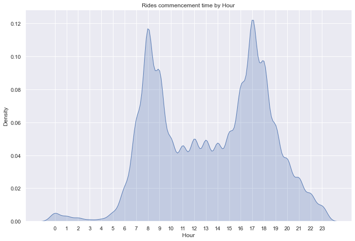

```python
plot_hour_kde('start_time_hour', "Rides commencement time by Hour")
```

The values in this plot corresponds to the number of rides started at different hours of the day. Majority of rides happen between 7 a.m. to 9 a.m. and 4 p.m. to 6 p.m. These are also the most common starting and closing hours for offices and schools.

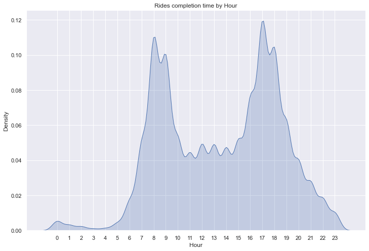

```python
plot_hour_kde('end_time_hour', "Rides completion time by Hour")
```

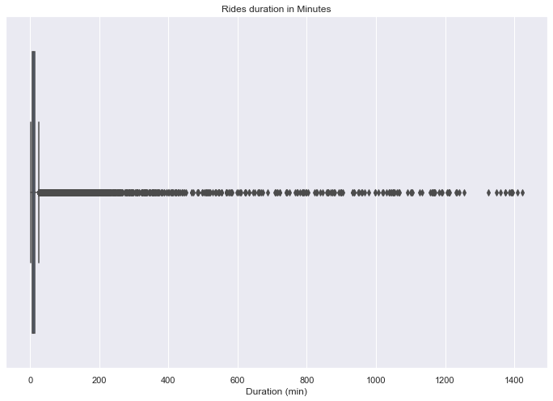

```python
sb.boxplot(data=bike_rides, x='duration_min')
plt.title("Rides duration in Minutes")
plt.xlabel("Duration (min)")
plt.show()
```

This boxplot shows the quartile distribution of rides duration. There are outliers in the minute duration rides rentals take.There are many rides about 60 minutes (1 Hour). It will be interesting to see the number and type of clients renting the rides for long durations.

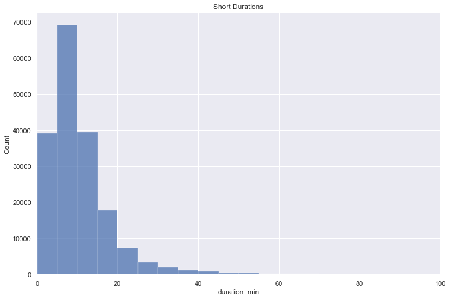

```python
bins = np.arange(0, 1500, 5)
sb.histplot(data=bike_rides, x='duration_min', bins=bins)
plt.xlim(0, 100)
plt.title("Short Durations")
plt.show()
```

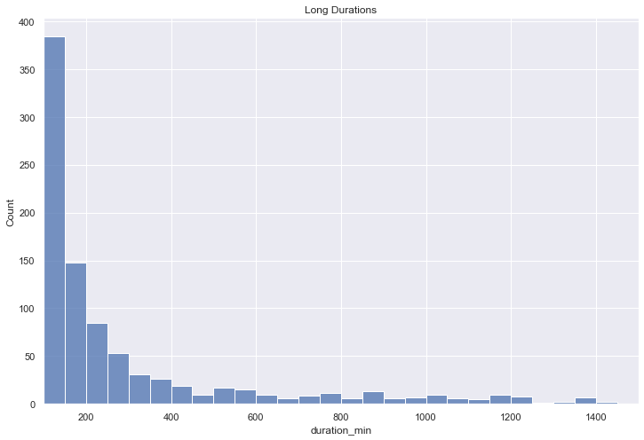

```python
bins = np.arange(100, 1500, 50)
sb.histplot(data=bike_rides, x='duration_min', bins=bins)
plt.xlim((100, 1500))
plt.title("Long Durations")
plt.show()
```

On the other hand, this (second) plot shows the distribution of ride rentals that took more than 100 minutes before completion. Even in the case of long duration rentals, most rides ended in less than 400 minutes.

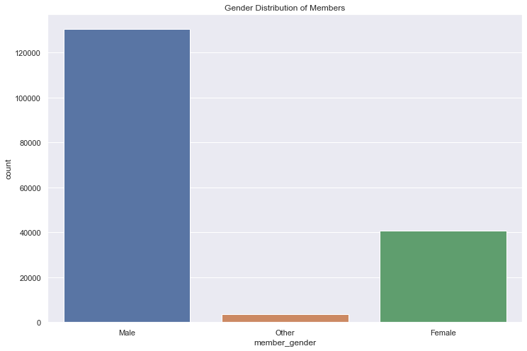

```python
sb.countplot(data=bike_rides, x='member_gender')
plt.title("Gender Distribution of Members")
plt.show()
```

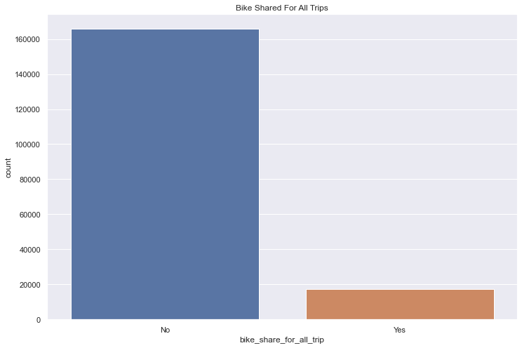

```python
sb.countplot(data=bike_rides, x='bike_share_for_all_trip')
plt.title("Bike Shared For All Trips")
plt.show()
```

```python
bike_rides['member_birth_year'].value_counts()
```

```
1988    10214
1993     9323
1989     8967
1990     8640
1991     8484
        ...
1944        2
1934        2
1928        1
1930        1
1927        1
Name: member_birth_year, Length: 70, dtype: Int64
```

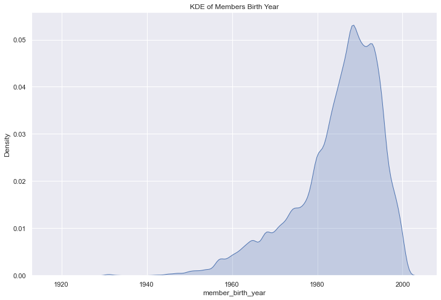

```python
sb.kdeplot(data=bike_rides, x='member_birth_year', shade=True)
plt.title("KDE of Members Birth Year")
plt.show()
```

Here we've plotted a distribution of member birth years. We excluded members born before 1919 because of the doubts those users took part in the ride rentals. Majority of clients are born after 1970. Only a handful of clients are born before 1950.

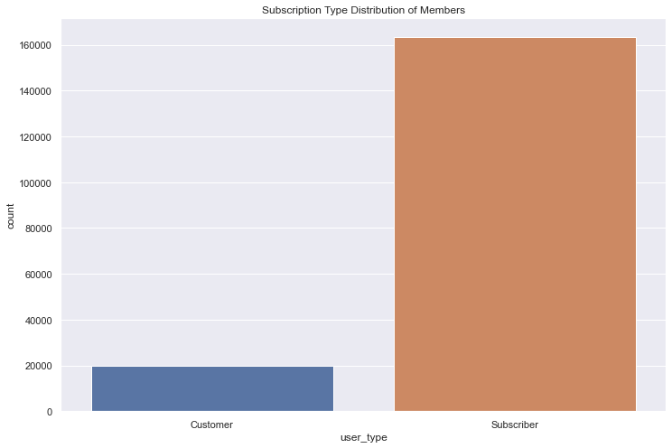

```python
sb.countplot(data=bike_rides, x='user_type')
plt.title("Subscription Type Distribution of Members")
plt.show()
```

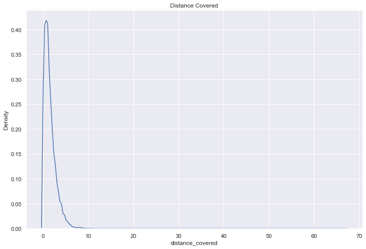

```python
sb.kdeplot(data=bike_rides, x='distance_covered')
plt.title("Distance Covered")
```

```python
bike_rides['start_station_name'].value_counts()
```

```
Market St at 10th St                                         3904
San Francisco Caltrain Station 2  (Townsend St at 4th St)    3542
Berry St at 4th St                                           3051
Montgomery St BART Station (Market St at 2nd St)             2895
Powell St BART Station (Market St at 4th St)                 2760
                                                             ...
Willow St at Vine St                                            9
Parker Ave at McAllister St                                     7
Palm St at Willow St                                            4
21st Ave at International Blvd                                  4
16th St Depot                                                   2
Name: start_station_name, Length: 329, dtype: int64
```

```python
bike_rides['end_station_name'].value_counts()
```

```
San Francisco Caltrain Station 2  (Townsend St at 4th St)    4855
Market St at 10th St                                         3973
Montgomery St BART Station (Market St at 2nd St)             3647
San Francisco Ferry Building (Harry Bridges Plaza)           3368
Powell St BART Station (Market St at 4th St)                 2997
                                                             ...
Parker Ave at McAllister St                                     9
Palm St at Willow St                                            7
16th St Depot                                                   6
21st Ave at International Blvd                                  6
Willow St at Vine St                                            5
Name: end_station_name, Length: 329, dtype: int64
```

### Of the features you investigated, were there any unusual distributions? Did you perform any operations on the data to tidy, adjust, or change the form of the data? If so, why did you do this?

> The dataset contained members born before 1919, this could have been a data entry error. I eliminated those members from the analysis.

## Bivariate Exploration

> In this section, investigate relationships between pairs of variables in your data. Make sure the variables that you cover here have been introduced in some fashion in the previous section (univariate exploration).

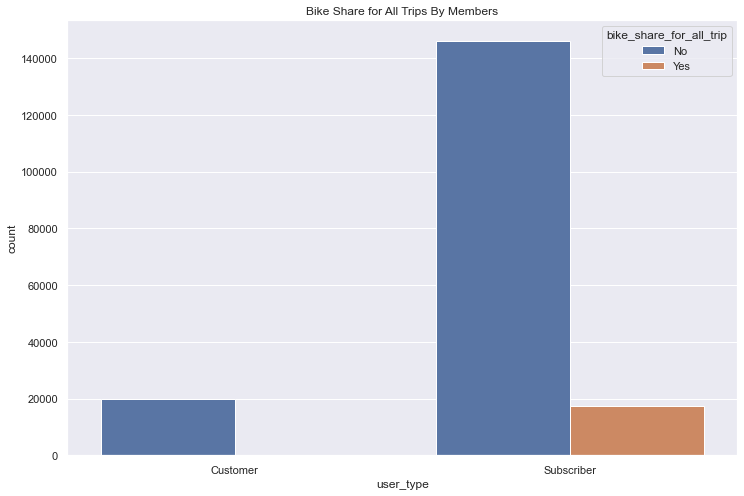

```python
sb.countplot(data=bike_rides, x='user_type', hue='bike_share_for_all_trip')
plt.title("Bike Share for All Trips By Members")
plt.show()
```

This plot shows the distribution of rides shared per user type. There are no rides shared among Customers. Ride Share for All Trips is only happened among Subscribers.

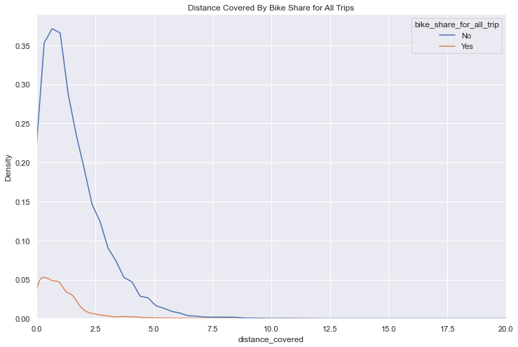

```python
sb.kdeplot(data=bike_rides, x='distance_covered', hue='bike_share_for_all_trip')
plt.xlim((0, 20))
plt.title("Distance Covered By Bike Share for All Trips")
plt.show()
```

This plot shows the distance covered per rides shared. Trips with bike shared cover shorter distances on average.

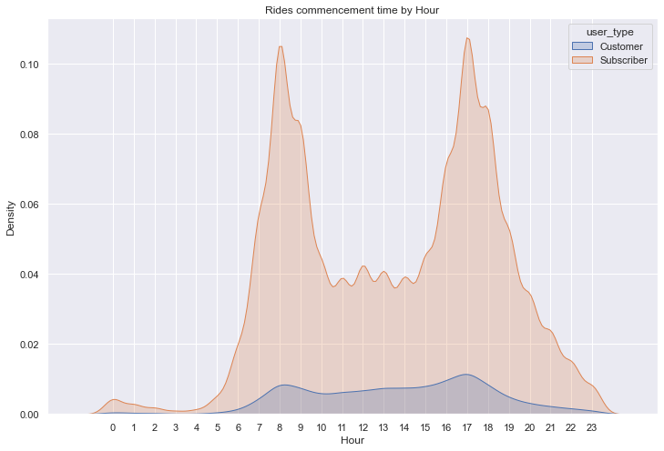

```python
plot_hour_kde('start_time_hour', "Rides commencement time by Hour", 'user_type')
```

The plot above shows the distibution of rides per hour among different types of members. There is a decline in usage between 10:00 and 15:00 among Subscribers. Around the same time there's a steady and growing amount rides among Customers.

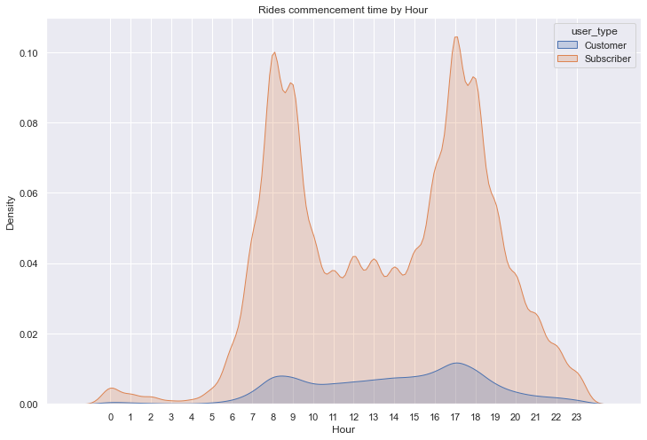

```python
plot_hour_kde('end_time_hour', "Rides commencement time by Hour", 'user_type')
```

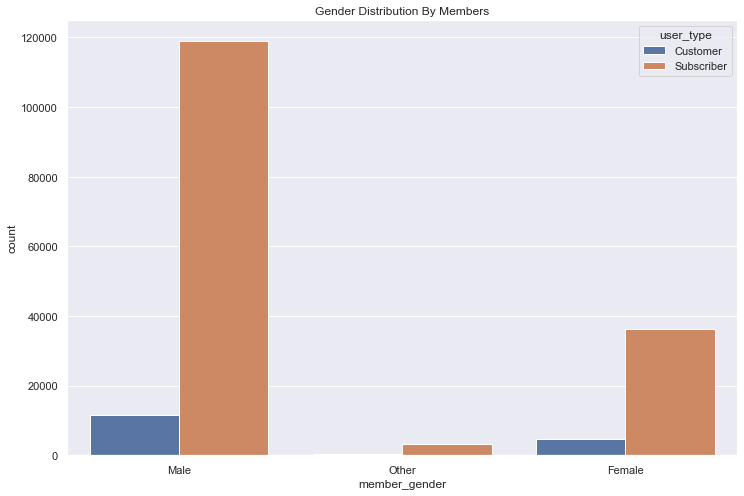

```python
sb.countplot(data=bike_rides, x='member_gender', hue='user_type')
plt.title("Gender Distribution By Members")
plt.show()
```

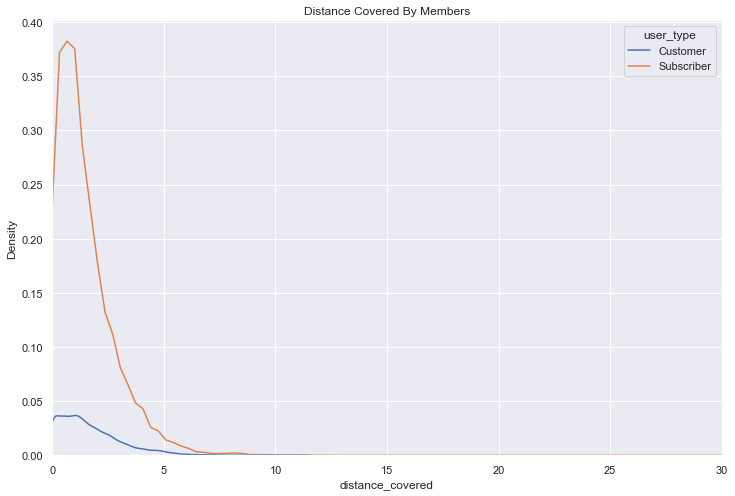

```python
sb.kdeplot(data=bike_rides, x='distance_covered', hue='user_type')
plt.xlim((0, 30))
plt.title("Distance Covered By Members")
plt.show()
```

This plot shows the distance covered by distribution of various member types. Subsribers tend to explore longer distances than Customers.

### Talk about some of the relationships you observed in this part of the investigation. How did the feature(s) of interest vary with other features in the dataset?

> The relationship between the `start_time_hour` and the `user_type` shows a drop in the amount of rides taken by subscribers while there is a steady growth in the amount of rides taken by customers. Similarly for the `start_time_hour` and `user_type` relationship.

### Did you observe any interesting relationships between the other features (not the main feature(s) of interest)?

> Trips cover longer distance when there is no `bike_share_for_all_trip`. And the trips are shorter when there is `bike_share_for_all_trip`.

## Multivariate Exploration

> Create plots of three or more variables to investigate your data even further. Make sure that your investigations are justified, and follow from your work in the previous sections.

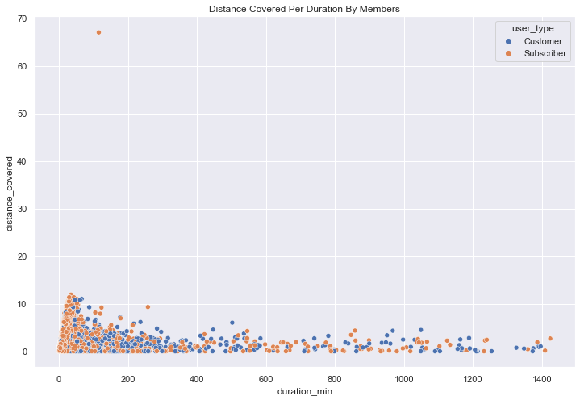

```python
sb.scatterplot(data=bike_rides, x='duration_min', y='distance_covered', hue='user_type')
plt.title("Distance Covered Per Duration By Members")
plt.show()
```

There's a cluster of duration per distance among Subscribers. This could mean that Subscribers follow similar routes and speed. While there's more variation among Customers.

```python
def plot_facetgrid(df, col, x, y):
    """
    Plot a FacetGrid with stripplot for a dataframe to display discrete values.
    """
    g = sb.FacetGrid(data=df, col=col, height=8)
    g.map(sb.stripplot, x, y, size=2, jitter=0.35, order=None)
    plt.show()
```

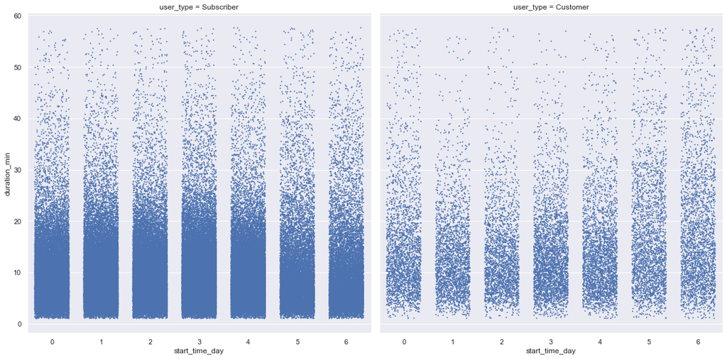

```python
plot_facetgrid(bike_rides.query('duration_min<duration_min.quantile(0.99)'), 'user_type', 'start_time_day', 'duration_min')
```

The plot above shows a daily distribution of time taken for each rides per members. The observation above shows that rides tend take longer duration on Day 6 (Sunday) for both Customers and Subscribers.

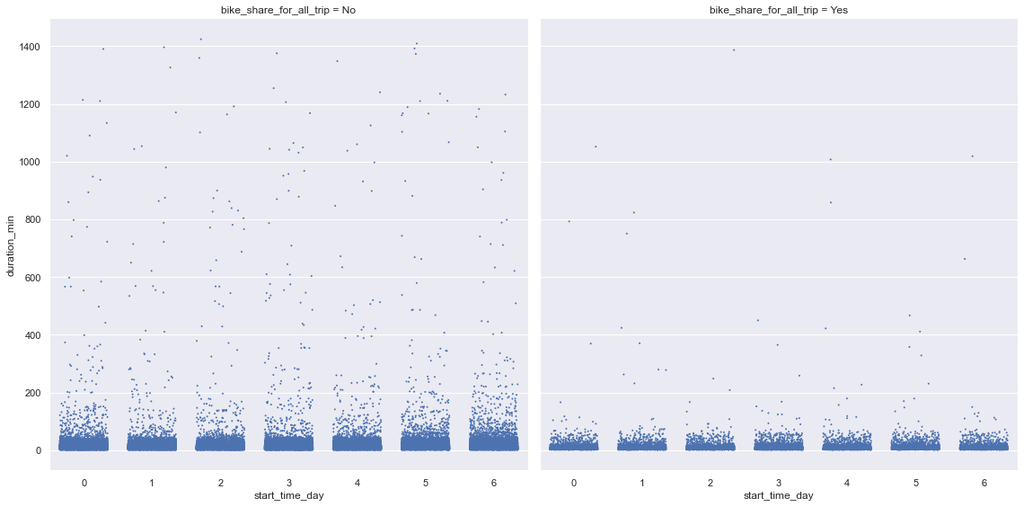

```python
plot_facetgrid(bike_rides, 'bike_share_for_all_trip', 'start_time_day', 'duration_min')
```

### Talk about some of the relationships you observed in this part of the investigation. Were there features that strengthened each other in terms of looking at your feature(s) of interest?

> Subscribers typically cover longer distances in shorter time span than Customer.

### Were there any interesting or surprising interactions between features?

> Yes, shared bike trips on Tuesday and Wednesday are typically shorted than the rest.

## Conclusions

Drawing on the observations found in the charts, these are some of the insights we can understand on the FordBike 2019 data.

> Subscribers mostly take rides between 7am to 9am and 4pm to 6pm while Customers have an almost steady increase in rides between 7am and 6pm.

> Subscribers also cover longer distances than Customers. Both members take longer rides on Sunday.

## References

["Pandas - Extract Hour from Timedelta"](https://stackoverflow.com/questions/52093199/pandas-extract-hour-from-timedelta)

["Getting distance between two points based on latitude/longitude"](https://stackoverflow.com/questions/19412462/getting-distance-between-two-points-based-on-latitude-longitude)